# Houston Labour-Market Time Series

A corrected quarterly forecasting comparison

Reway Du

Portfolio edition — August 2026

# 1 Executive summary

This project revisits a two-part university time-series assignment using a clean, frequency-correct pipeline. It compares separate seasonal ARMA models with a two-variable VAR and a seasonal-naive baseline for one-quarter-ahead forecasts of Houston-area unemployment and average weekly wages.

The analysis uses 141 aligned quarters from 1990 Q1 through 2025 Q1. Models are initially selected using data through 2017 Q4; the final 29 quarters are evaluated with an expanding training window.

The univariate models produced the lowest RMSE for both series. Unemployment RMSE was 2.29 percentage points, versus 2.73 for the seasonal-naive baseline and 2.91 for the VAR. Wage RMSE was $39.32, versus $61.36 and $57.42, respectively.

This is evidence about forecast accuracy under one historical evaluation—not a causal conclusion and not proof that wages and unemployment are unrelated.

# 2 Data and frequency alignment

The two public FRED series have different native frequencies and units:

- [`HOUS448URN`](https://fred.stlouisfed.org/series/HOUS448URN) is a monthly, not-seasonally-adjusted unemployment rate in percent.
- [`ENUC264240010`](https://fred.stlouisfed.org/series/ENUC264240010) is a quarterly, not-seasonally-adjusted average weekly wage in dollars per week.

For every retained quarter, the unemployment rate is the arithmetic mean of all three monthly observations. The wage observation is then joined by the same quarter date. No vector recycling, row-position matching, or unequal-length `cbind` is used.

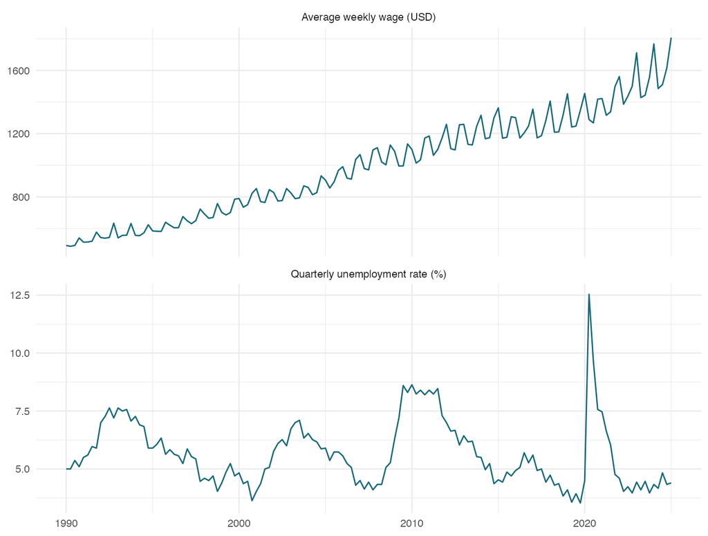

Aligned quarterly unemployment and average weekly wage series.

The wage series is not a minimum-wage measure. It covers average weekly wages paid by unemployment-insurance-covered employers. The two source titles also use different historical Houston MSA names; this analysis does not assume that geographic definitions remained perfectly unchanged.

# 3 Transformations and stationarity diagnostics

The modeled annual transformations are

$$\Delta_4 u_t = u_t-u_{t-4}, \qquad
g^{(4)}_t = \log(w_t)-\log(w_{t-4}),$$

where four lags correspond to one year of quarterly data. A lag of 12 would be three years and is not used as a quarterly seasonal difference.

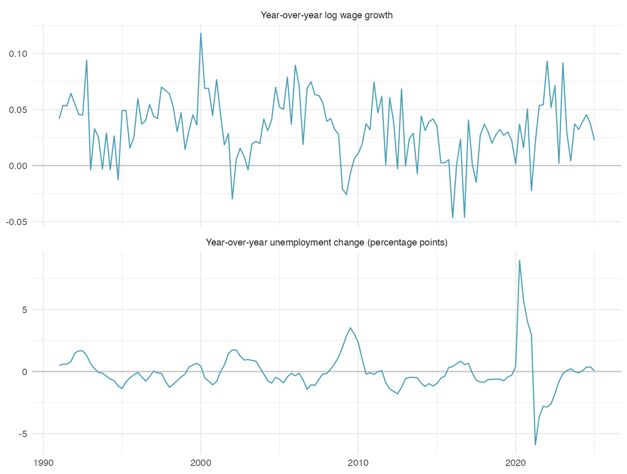

Year-over-year transformations used for modeling.

Complementary stationarity diagnostics on the frozen snapshot.

| Series | N | ADF p-value | KPSS-level p-value |
| --- | --- | --- | --- |
| Unemployment rate (level) | 141 | 0.0285 | 0.10 |
| Log weekly wage (level) | 141 | 0.6238 | 0.01 |
| Year-over-year change in unemployment | 137 | 0.0100 | 0.10 |
| Year-over-year log wage growth | 137 | 0.0100 | 0.10 |

The ADF null is a unit root, while the KPSS-level null is level stationarity. For both annual transformations, the ADF test rejects its null and the KPSS test does not reject its null at 5%. These tests have limited power and are treated as diagnostics, not proof that the data-generating process is fixed forever.

# 4 Model selection

Univariate candidates span non-seasonal orders $p,q\in\{0,1,2,3\}$ and seasonal orders $P,Q\in\{0,1\}$ with quarterly period four and at most four total AR/MA terms. Selection uses only the initial training sample. A candidate must have a 12-lag Ljung–Box p-value of at least 0.05, after adjusting for fitted AR/MA terms; among passing candidates, the lowest AICc is selected.

Initial-training model choices.

| Component | Selected value |
| --- | --- |
| Unemployment univariate SARMA model | SARMA(2,0)(0,1)[4] |
| Wage univariate SARMA model | SARMA(3,1)(0,0)[4] |
| Univariate selection rule | Lowest training AICc among candidates passing a 12-lag Ljung-Box check at 5% |
| VAR lag | 3 |
| Maximum VAR companion root modulus | 0.8670 |

Residual-autocorrelation checks on the initial training fits.

| Series | Selected model | Lag | Ljung–Box statistic | p-value | Conclusion |
| --- | --- | --- | --- | --- | --- |
| Year-over-year change in unemployment | SARMA(2,0)(0,1)[4] | 12 | 6.69 | 0.670 | No residual autocorrelation detected at 5% |
| Year-over-year log wage growth | SARMA(3,1)(0,0)[4] | 12 | 15.40 | 0.052 | No residual autocorrelation detected at 5% |

A Ljung–Box p-value below 0.05 would indicate remaining residual autocorrelation; it would not establish stationarity. The selected models pass this initial check, although passing one diagnostic does not guarantee correct specification.

# 5 Out-of-sample design

For every quarter from 2018 Q1 through 2025 Q1, each model is refit using only data available before that target quarter. All methods make the same one-step-ahead point forecast:

1. the seasonal-naive forecast repeats the same quarter from the previous year;
2. each SARMA model forecasts its own annual transformation and reconstructs the level from the same quarter one year earlier; and
3. the VAR jointly forecasts the two annual transformations and reconstructs both levels in the same way.

This avoids comparing a rolling one-step forecast from one model with a fixed- origin multi-step forecast from another.

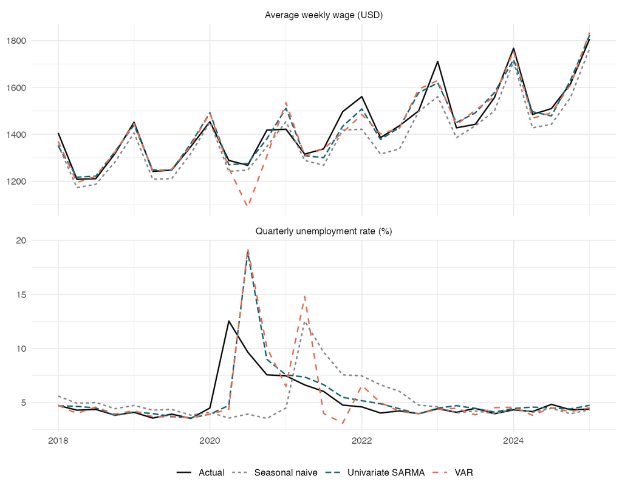

Expanding-window, one-quarter-ahead forecasts.

Point-forecast error over the 29-quarter evaluation.

| Target | Model | Metric | Value |
| --- | --- | --- | --- |
| Average weekly wage (USD) | Univariate SARMA | MAE | 29.805 |
| Average weekly wage (USD) | VAR | MAE | 37.299 |
| Average weekly wage (USD) | Seasonal naive | MAE | 51.207 |
| Average weekly wage (USD) | Univariate SARMA | RMSE | 39.315 |
| Average weekly wage (USD) | VAR | RMSE | 57.425 |
| Average weekly wage (USD) | Seasonal naive | RMSE | 61.360 |
| Quarterly unemployment rate | Univariate SARMA | MAE | 0.905 |
| Quarterly unemployment rate | VAR | MAE | 1.404 |
| Quarterly unemployment rate | Seasonal naive | MAE | 1.682 |
| Quarterly unemployment rate | Univariate SARMA | RMSE | 2.293 |
| Quarterly unemployment rate | Seasonal naive | RMSE | 2.734 |
| Quarterly unemployment rate | VAR | RMSE | 2.910 |

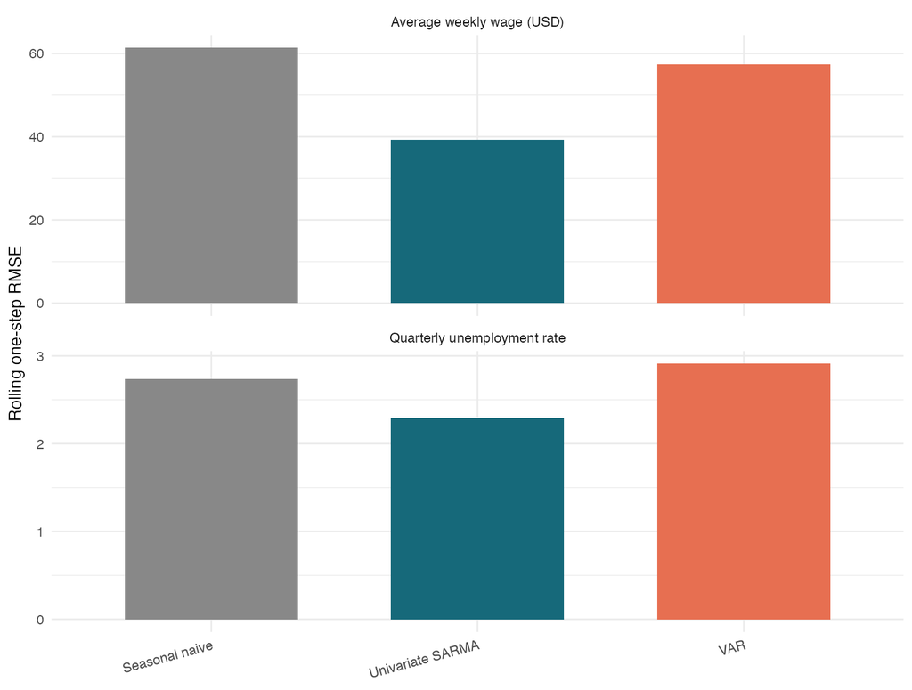

RMSE comparison using a common evaluation design.

# 6 Limitations

- The evaluation has only 29 quarters and includes the unusually large 2020 labour-market disruption; forecast rankings may differ in a calmer period.
- A fixed 80/20 chronological split is transparent but does not quantify uncertainty in model-ranking differences.
- ADF, KPSS, AICc, and Ljung–Box checks each answer narrow questions and cannot prove model truth.
- The selected wage model’s initial Ljung–Box p-value is only about 0.052, very close to the 0.05 screen; its residual adequacy should therefore be described as borderline rather than conclusive.
- FRED/BLS observations can be revised after the frozen download.
- The series are not seasonally adjusted and may reflect changing metropolitan definitions and reporting practices.
- The VAR is a forecasting benchmark. No structural identification, exogenous controls, Granger-causality study, or causal interpretation is attempted.
- Only point forecasts are scored; production use would also require calibrated forecast intervals and monitoring for structural breaks.

# 7 Conclusion

Correct frequency alignment changes the project from an invalid monthly/ quarterly comparison into a reproducible forecasting exercise. On this frozen sample and evaluation window, separate seasonal ARMA models forecast both targets more accurately than the fitted VAR and seasonal-naive alternatives. The most defensible conclusion is therefore modest: a joint linear dynamic model did not add point-forecast value here.

# 8 Portfolio and authorship note

The earlier two-part submission was completed collaboratively by Reway Du and three peers. It contains no task-level contribution table, so this rewrite does not assign sole original authorship to Reway. Student numbers, assignment prompts, teammate names, and the original AI-percentage table are omitted.

# 9 Computing environment

```r
cat(
  readLines(
    project_file("results", "session-info.txt")
  ),
  sep = "\n"
)
```

[output not shown]